# MATH9102-W11-LogReg

Author

Deirdre Lawless

In this lab we will be using the Youth Cohort Dataset (from Paul Connolly’s Quantitative Data Analysis in Education). This dataset is drawn from a large-scale survey of young people carried out in the UK. It contains demographic, educational, and attitudinal variables. The dataset includes information such as gender, social class, schooling experiences, academic attainment, and post-school aspirations.

We will examine how well we can predict educational attainment — specifically whether a student sat French at GCSE level — using broader social factors such as parental education and school type.

Participation in modern foreign languages (MFLs) such as French is widely used in educational research as an indicator of both academic engagement and curricular opportunity. Unlike core subjects, MFL entry is not compulsory in many schools, meaning that a student’s decision (or ability) to take French often reflects a combination of:

- School characteristics (e.g., whether MFL is strongly promoted or timetabled in ways that facilitate uptake)
- Family background and resources (e.g., parental education, expectations, and cultural capital)
- Student academic confidence and aspirations, particularly in more academically aligned pathways

Because MFL subjects tend to be taken more often by students on higher-attainment or academically oriented tracks, uptake in subjects like French has consistently been shown to correlate with broader patterns of educational advantage, expectations of further study, and school-level guidance practices.

# Model 1; Simple Binary Logistic Regression

This model explores whether parental educational achievement helps predict a young person’s likelihood of answering yes to whether they sat French at GCSE level. - satfren is the binary outcome (Yes = sat GCSE French, No = did not - converted to a factor satfren_num 1 = sat GCSE maths, 0 = No did not) - s1pared is the sole predictor (At least one parent with degree, 2 At least one parent with A-level, 3 Neither parent with A-level) - This will allow us to estimate how differences in parental education are associated with the probability that a student sat GCSE French.

## Step 0: Descriptives and Visuals

```r
youthdf %>%
janitor::tabyl(satfren) %>%
adorn_percentages("col") %>%
adorn_pct_formatting(digits = 1)
```

```
 satfren   n percent
      No 0.4   44.2%
     Yes 0.6   55.8%
```

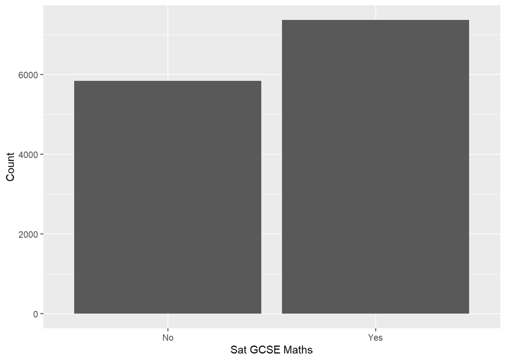

Figure 1: Distribution of GCSE French Participation

```r
ggplot(youthdf, aes(x = satfren)) +
geom_bar() +
labs(x = "Sat GCSE Maths", y = "Count")
```

```r
youthdf %>%
janitor::tabyl(s1pared) %>%
adorn_percentages("col") %>%
adorn_pct_formatting(digits = 1)
```

```
                          s1pared   n percent
      Neither parent with A-level 0.5   48.8%
 At least one parent with A-level 0.2   21.4%
  At least one parent with degree 0.3   29.8%
```

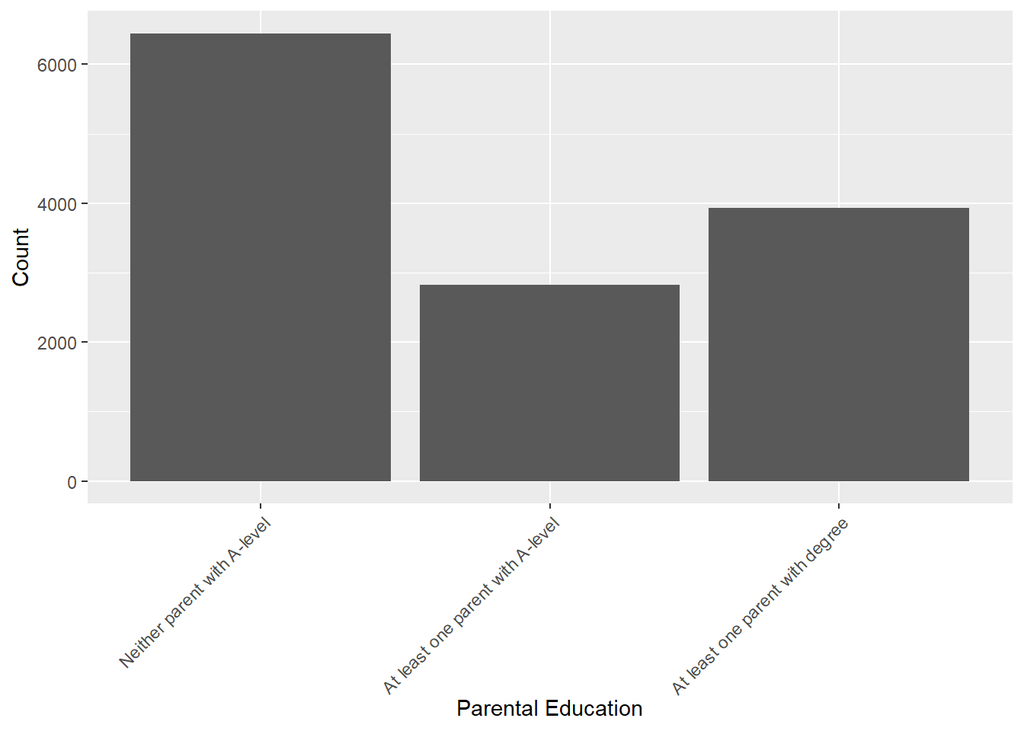

Figure 2: Distribution of Parental Education Levels

```r
ggplot(youthdf, aes(x = s1pared)) +
geom_bar() +
labs(x = "Parental Education", y = "Count") +
theme(axis.text.x = element_text(angle = 45, hjust = 1))
```

```r
youthdf %>%
  tabyl(satfren, s1pared) %>%
  adorn_percentages("col") %>%
  adorn_pct_formatting(digits = 1)
```

```
 satfren Neither parent with A-level At least one parent with A-level
      No                       49.4%                            43.2%
     Yes                       50.6%                            56.8%
 At least one parent with degree
                           36.5%
                           63.5%
```

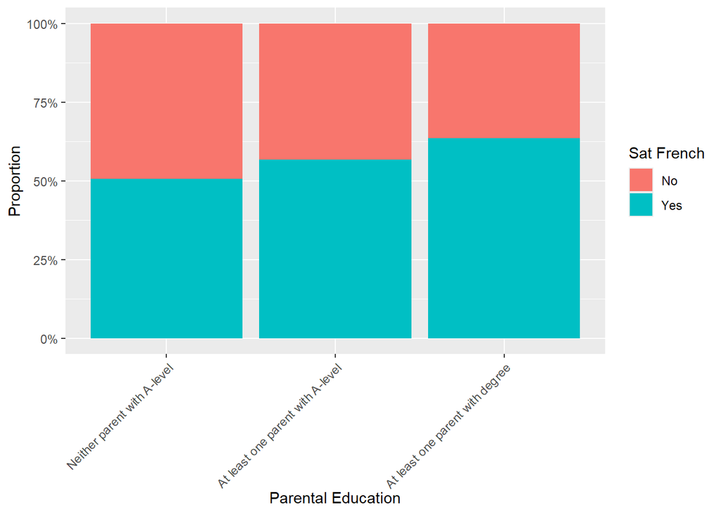

Figure 3: Proportion Sitting GCSE French by Parental Education

```r
ggplot(youthdf, aes(x = s1pared, fill = satfren)) +
geom_bar(position = "fill") +
scale_y_continuous(labels = scales::percent_format()) +
labs(x = "Parental Education", y = "Proportion", fill = "Sat French") +
theme(axis.text.x = element_text(angle = 45, hjust = 1))
```

```r
# Chi square test
chisq.test(table(youthdf$satfren_num, youthdf$s1pared, useNA = "no"))
```

```
    Pearson's Chi-squared test

data:  table(youthdf$satfren_num, youthdf$s1pared, useNA = "no")
X-squared = 165.05, df = 2, p-value < 2.2e-16
```

```r
# Get the sample size
sum(complete.cases(youthdf[, c("satfren", "s1pared")]))
```

```
[1] 13201
```

```r
#Calculate effect size

tab <- table(youthdf$satfren, youthdf$s1pared)

chi2 <- 165.05       # your chi-square value
n    <- sum(tab)     # total sample size
k    <- min(nrow(tab), ncol(tab))

cramers_v <- sqrt(chi2 / (n * (k - 1)))
cramers_v
```

```
[1] 0.1118161
```

## Step 1: Build the model

```r
# Outcome must be 0/1
logmodel1 <- glm(satfren_num ~ s1pared, data =youthdf, na.action = na.exclude, family = binomial(link=logit))
```

## Step 2: Generate Summary Statisics to Assess model fit

### Step 2a: Summary of Model

This includes all information needed about the model but requires some calculation and additional information to fully assess the fit and usefulness. Additional tests will provide easier access to some parts, we will use elements of this when looking at the odds ratios.

```r
#Full summary of the model
summary(logmodel1)
```

```
Call:
glm(formula = satfren_num ~ s1pared, family = binomial(link = logit),
    data = youthdf, na.action = na.exclude)

Coefficients:
                                        Estimate Std. Error z value Pr(>|z|)
(Intercept)                              0.02544    0.02491   1.021    0.307
s1paredAt least one parent with A-level  0.24716    0.04545   5.439 5.37e-08
s1paredAt least one parent with degree   0.52779    0.04144  12.736  < 2e-16

(Intercept)
s1paredAt least one parent with A-level ***
s1paredAt least one parent with degree  ***
---
Signif. codes:  0 '***' 0.001 '**' 0.01 '*' 0.05 '.' 0.1 ' ' 1

(Dispersion parameter for binomial family taken to be 1)

    Null deviance: 18124  on 13200  degrees of freedom
Residual deviance: 17958  on 13198  degrees of freedom
AIC: 17964

Number of Fisher Scoring iterations: 4
```

### Step 2b: Omnibus Test of Model

Tells us whether the model as a whole is significant. Gives us the Chi Square statistic to report for the model as a whole.

```r
#Chi-square plus significance
lmtest::lrtest(logmodel1)
```

```
Likelihood ratio test

Model 1: satfren_num ~ s1pared
Model 2: satfren_num ~ 1
  #Df  LogLik Df  Chisq Pr(>Chisq)
1   3 -8978.9
2   1 -9062.0 -2 166.19  < 2.2e-16 ***
---
Signif. codes:  0 '***' 0.001 '**' 0.01 '*' 0.05 '.' 0.1 ' ' 1
```

## (Optional): Use Stargazer to Report

```r
#Summary of the model with co-efficients
stargazer(logmodel1, type="text", star.cutoffs = c(0.05, 0.01, 0.001))
```

```
=====================================================================
                                             Dependent variable:
                                        -----------------------------
                                                 satfren_num
---------------------------------------------------------------------
s1paredAt least one parent with A-level           0.247***
                                                   (0.045)

s1paredAt least one parent with degree            0.528***
                                                   (0.041)

Constant                                            0.025
                                                   (0.025)

---------------------------------------------------------------------
Observations                                       13,201
Log Likelihood                                   -8,978.861
Akaike Inf. Crit.                                17,963.720
=====================================================================
Note:                                   *p<0.05; **p<0.01; ***p<0.001
```

### Step 2c: Pseudo R2 Statistics

Pseudo R2 statistics tell us how much better does the model fit the data compared to a baseline model (a model with no predictors)?

```r
#Pseudo R Squared
DescTools::PseudoR2(logmodel1, which="CoxSnell")
```

```
  CoxSnell
0.01250994
```

```r
DescTools::PseudoR2(logmodel1, which="Nagelkerke")
```

```
Nagelkerke
0.01675513
```

```r
performance::r2(logmodel1) # Will return Tujur's Pseudo R2
```

```
# R2 for Logistic Regression
  Tjur's R2: 0.013
```

The logistic regression model examining whether parental education predicts GCSE French participation was statistically significant. A likelihood ratio test comparing the fitted model to the null model indicated improved fit, χ²(2, N = 13,201) = 166.19, p < .001.

However, effect size indices showed that parental education contributed only modest explanatory power:

Cox–Snell R² = .013

Nagelkerke R² = .017

Tjur’s R² = .013

These values indicate that parental education explains between 1.3% and 1.7% of the variation in whether students sat French at GCSE. The predictor is statistically significant due to the large sample size, but its practical impact on prediction is small.

## Step 3: Calculate Odds Ratios and Probability of Co-efficients

```r
# Odds ratios only
parameters::parameters(logmodel1, exponentiate = TRUE) %>%
  as.data.frame() %>%
  dplyr::select(Parameter, OddsRatio = Coefficient)
```

```
Profiled confidence intervals may take longer time to compute.
  Use `ci_method="wald"` for faster computation of CIs.
```

```
                                Parameter OddsRatio
1                             (Intercept)  1.025762
2 s1paredAt least one parent with A-level  1.280386
3  s1paredAt least one parent with degree  1.695187
```

```r
# Predicted probabilities by s1pared
emmeans::emmeans(logmodel1, ~ s1pared, type = "response")
```

```
 s1pared                           prob      SE  df asymp.LCL asymp.UCL
 Neither parent with A-level      0.506 0.00623 Inf     0.494     0.519
 At least one parent with A-level 0.568 0.00933 Inf     0.549     0.586
 At least one parent with degree  0.635 0.00768 Inf     0.620     0.650

Confidence level used: 0.95
Intervals are back-transformed from the logit scale
```

When we run the logistic regression, R automatically chooses a reference category for our categorical predictor. In this model, the reference group is:

“Neither parent with A-level”

This means that all odds ratios compare each other parental-education group to this baseline group.

When interpreting the **odds ratios**, there are two things to look for:

1. Is the odds ratio greater than 1 or less than 1?

OR > 1 → higher odds of sitting French compared to the reference group

OR < 1 → lower odds compared to the reference group

2. Is the effect statistically significant?

Look at the p-value for each coefficient

p < .05 → statistically significant

**Group: At least one parent with a degree**

OR ≈ 1.70

This means: Students whose parents have a degree have 70% higher odds of taking GCSE French than students whose parents do not have an A-level.

The effect is statistically significant.

**Group: At least one parent with an A-level**

OR ≈ 1.28

This means: Students with a parent who has an A-level have higher odds of taking French than the reference group - 28% higher odds.

Also statistically significant.

**Reference Group: Neither parent has an A-level**

OR = 1.00, because this is the baseline.

Every other group is compared to this one.

Odds ratios tell us how the odds increase or decrease, but ** predicted probabilities** are easier to understand.

R gives us predicted probabilities for each group:

- Parents with degree: ~0.63
- At least one parent with A-level: ~0.57
- Neither parent with A-level: ~0.51

What does this tell us?

- Students with more highly educated parents are more likely to have taken GCSE French.
- The differences are real but modest: only about a 12-percentage-point difference between the highest and lowest groups.

## Step 4: Assess Classification Performance

### Step 4a: Generate a ROC curve and Calculate Sensitivity, Specificity and AUC

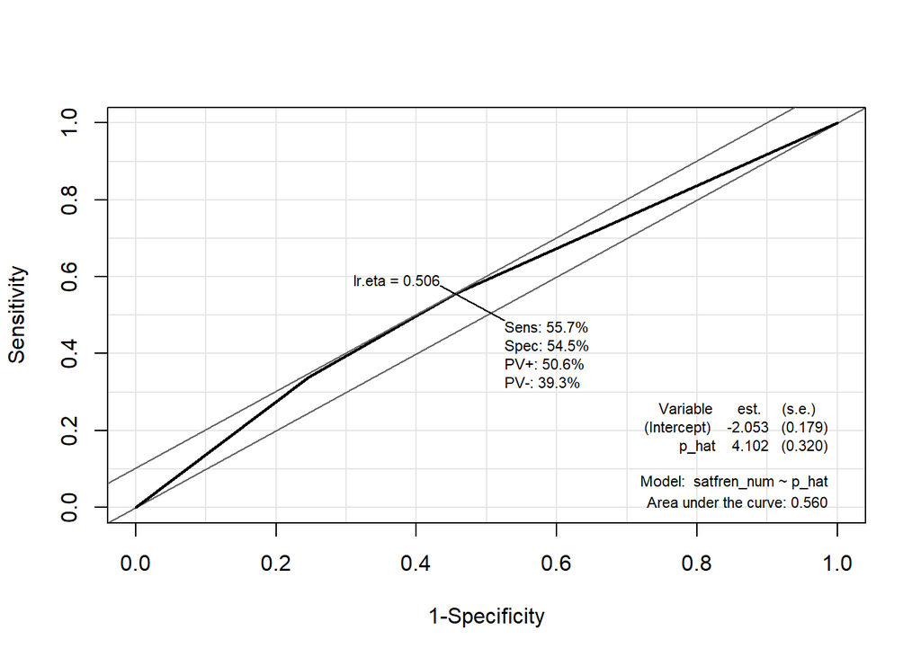

Figure 4: ROC curve for Model1

```r
# Generate predicted probabilities for Model 1
p_hat <- stats::predict(logmodel1, type = "response")

# Build results1 data frame for Epi::ROC
results1 <- youthdf %>%
  dplyr::mutate(
    satfren_num = satfren_num,   # already created earlier
    p_hat = p_hat                # predicted probabilities
  ) %>%
  dplyr::select(satfren_num, p_hat) %>%     # only keep needed columns
  dplyr::filter(!is.na(satfren_num))        # remove NA cases

# Generate the curve
roc1 <-Epi::ROC(
  form = satfren_num ~ p_hat,
  data = results1,
  plot = "ROC"
)
```

A ROC curve (Receiver Operating Characteristic curve) is a way of checking how well the model can distinguish between the two outcome groups:

- Sat French (1)
- Did not sit French (0)

The important result is the AUC (Area Under the Curve).

What does AUC mean?

- AUC = 0.50 → model performs no better than random guessing
- AUC = 1.00 → perfect prediction
- AUC between 0.5 and 0.7 → poor discrimination
- AUC between 0.7 and 0.8 → acceptable

In our model AUC = 0.56. The model performs only slightly better than chance.

Even though parental education is statistically significant, it does not help the model separate students who took French from those who didn’t.

Hey point: Statistical significance does not guarantee good prediction. A predictor can be statistically related to the outcome but still be weak at classifying individual cases.

### Step 4b: Generate a Confusion Matrix

```r
results1 <- youthdf %>%
  dplyr::mutate(
    actual = factor(satfren_num, levels = c(0,1)),
    pred_class = factor(
      ifelse(stats::predict(logmodel1, type = "response") > 0.5, 1, 0),
      levels = c(0,1)
    )
  )


cm <- yardstick::conf_mat(
  data = results1,
  truth = actual,
  estimate = pred_class
)

cm
```

```
          Truth
Prediction    0    1
         0    0    0
         1 5838 7363
```

A Confusion Matrix compares:

- Actual values (did the student take French?) with
- Predicted values (what the model says at a probability cutoff, usually 0.5)

The matrix gives:

- True Positives (TP): predicted Yes & actually Yes
- True Negatives (TN): predicted No & actually No
- False Positives (FP): predicted Yes but actually No

In our model, using the standard 0.5 cutoff, the model predicted almost everyone as “Yes” (sat French)

This creates very high sensitivity (we catch almost all the Yes cases) and very low specificity (we miss almost all the No cases). Why: The predicted probabilities from the model are all very close together (around 0.51 to 0.63). Since most probabilities are above 0.5, the model classifies nearly everyone as “Yes”

Sensitivity measures how well the model identifies the Yes cases: Of all the students who actually sat French, how many did the model correctly identify as “Yes”? High sensitivity means the model is good at detecting students who did take French. Low sensitivity means the model misses many Yes cases.

Specificity measures how well the model identifies the No cases: Of all the students who did not sit French, how many did the model correctly identify as “No”? High specificity means the model is good at detecting students who did not take French. Low specificity means the model predicts “Yes” too often.

In our model because almost all predicted probabilities were slightly above 0.5, the model predicted nearly every student as “Yes”. This produces High sensitivity - the model correctly identifies almost all the students who actually sat French, because it predicts “Yes” for nearly everyone. So nearly all true Yes cases get caught. And Very low specificity - the model almost never predicts “No”. So it fails to identify students who did not take French. These become false positives

## Step 5: Check Model Meets Assumptions of Logistic Regression

### Step 5a: Linearity of Independent Variables and Log Odds

```r
#Check the assumption of linearity of independent variables and log odds using a Hosmer-Lemeshow test, if this is not statistically significant we are ok
generalhoslem::logitgof(youthdf$satfren_num, fitted(logmodel1))
```

```
    Hosmer and Lemeshow test (binary model)

data:  youthdf$satfren_num, fitted(logmodel1)
X-squared = 2.5495e-24, df = 0, p-value < 2.2e-16
```

### Step 5b: Collinearity

```r
#We would check for collinearity here but as we only have one predictor it doesn't make sense - check model 2 to see how to do this
```

### Step 5c: Outliers and Influential Cases

Although logistic regression does not require the residuals to be normally distributed, it is still important to check for outliers and influential cases. Individual observations with unusually large residuals, high leverage, or strong influence can distort coefficient estimates, odds ratios, and overall model fit. Minimal diagnostic checks—such as Cook’s Distance, leverage values, standardised residuals, and DFBetas—help identify whether any single case is exerting undue influence on the model. These checks do not require the removal of observations but allow us to confirm that the results are not being driven by a small number of extreme or unusual cases. - **Cook’s Distance**: Measures how much each individual observation influences the overall model; large values indicate cases that may disproportionately affect the results.

- **Leverage (Hat values)**: Identifies observations with unusual predictor values; high-leverage cases have the potential to pull the model toward themselves.
- **Standardised (Pearson) residuals**: Show how poorly each observation is predicted by the model; large residuals (e.g., > |2|) indicate unusual or poorly fitted cases.
- **Deviance residuals**: Reflect how much each observation contributes to the model’s deviance; large values highlight observations the model struggles to accurately classify.
- **DFBetas**: Measure how much each observation influences individual regression coefficients; large DFBetas indicate that removing the case would substantially change a coefficient estimate.

```r
# 1. Cook's Distance
cook <- cooks.distance(logmodel1)

# View largest Cook's D values
head(sort(cook, decreasing = TRUE))
```

```
         50         119         121         122         156         200
0.000155355 0.000155355 0.000155355 0.000155355 0.000155355 0.000155355
```

```r
# Flag influential cases (common threshold: D > 1)
which(cook > 1)
```

```
named integer(0)
```

```r
# 2. Leverage (Hat values)
lev <- hatvalues(logmodel1)

# View highest leverage cases
head(sort(lev, decreasing = TRUE))
```

```
          10           13           17           19           50           66
0.0003546099 0.0003546099 0.0003546099 0.0003546099 0.0003546099 0.0003546099
```

```r
# Flag high leverage cases
# Rule of thumb: h_i > 2*(k+1)/n
k <- length(coef(logmodel1)) - 1  # number of predictors
n <- nobs(logmodel1)
lev_threshold <- 2*(k+1)/n
which(lev > lev_threshold)
```

```
named integer(0)
```

```r
# 3. DFBetas (influence on individual coefficients)
dfb <- dfbeta(logmodel1)

# Identify cases with large DFBetas (|DFB| > 1 is concerning)
which(abs(dfb) > 1, arr.ind = TRUE)
```

```
     row col
```

```r
# 4. Standardised (Pearson) residuals
pearson_resid <- rstandard(logmodel1, type = "pearson")

# Flag large residuals (|residual| > 2 or > 3)
which(abs(pearson_resid) > 2)
```

```
named integer(0)
```

```r
# Optional: look at the largest ones
head(sort(abs(pearson_resid), decreasing = TRUE))
```

```
       2        9       26       29       34       39
1.318825 1.318825 1.318825 1.318825 1.318825 1.318825
```

```r
# 5. Deviance residuals
dev_resid <- residuals(logmodel1, type = "deviance")

# Flag extreme deviance residuals
which(abs(dev_resid) > 2)
```

```
named integer(0)
```

The Hosmer-Lemeshow test checks goodness of fit by grouping data into deciles of predicted probability.

It does not necessarily indicate a bad model. It just tells us that the data structure prevents this test from working

Multicollinearity is not applicable here because there is only one predictor.

## Step 6: Report

A binary logistic regression was conducted to examine whether parental education level predicted the likelihood that a student sat GCSE French. The analysis was based on a sample of 13,201 students. The outcome variable was coded 0 = Did not sit French and 1 = Sat French. Parental education had three levels - At least one parent with degree - At least one parent with A-level - Neither parent with A-level with Neither (reference category).

The overall model was statistically significant, χ²(2, N = 13,201) = 166.19, p < .001, indicating that parental education improved prediction compared to a null model with no predictors. However, effect-size measures (pseudo R²) showed that the inclusion of parental education as a predictor improved model fit only slightly when compared to the baseline (intercept-only) model (Cox–Snell R² = .013, Nagelkerke R² = .017, Tjur’s R² = .013), indicating that the predictor contributed minimally to the model’s explanatory power. This suggests that although parental education is related to the outcome, its practical contribution to predicting who takes French is limited.

Using “Neither parent with an A-level” as the reference category:

- Students with at least one parent holding a degree had significantly higher odds of taking French (OR ≈ 1.70, p < .001).
- Students with at least one parent holding an A-level also had higher odds of taking French (OR ≈ 1.28, p < .001).

Predicted probabilities followed a similar pattern:

- At least one parent with a degree: ~0.64
- At least one parent with an A-level: ~0.57
- Neither parent with an A-level (reference): ~0.51

These results show that higher parental education is associated with a greater likelihood of taking GCSE French, but the differences between groups remain modest.

The model’s predictive performance was evaluated using a ROC curve and confusion matrix. The AUC was 0.56, indicating poor discrimination. Using a 0.5 classification threshold, the model predicted nearly all students as having taken French. This led to:

- High sensitivity (correctly identifying most students who did take French), but
- Very low specificity (failing to identify those who did not take French)

This pattern occurred because predicted probabilities for all students were close to the overall base rate, leaving very little separation between the Yes and No groups. As a result, the model performed poorly as a classifier.

The Hosmer–Lemeshow goodness-of-fit test could not be meaningfully applied due to the distribution of the outcome and the similarity in predicted probabilities across groups. This reflects the structure of the dataset rather than model misfit. Multicollinearity was not assessed because the model contained only one predictor, making it impossible. Influence diagnostics were examined to ensure that the logistic regression results were not unduly affected by individual cases. Cook’s Distance values were all extremely small (D < 0.001), and no observations exceeded the common influence threshold of 1, indicating that no single case exerted unusual influence on the overall model. Leverage values were uniformly low suggesting that no observations had unusual combinations of predictor values. Standardised Pearson residuals and deviance residuals showed no cases of concern DFBetas revealed no instances where the removal of a case would substantially alter any regression coefficient. Taken together, these diagnostics indicate that the results of Model 1 are stable and not driven by a small number of influential points.

Overall, there were no clear indications of violations of logistic regression assumptions.

**Conclusion**

Parental education is statistically associated with whether students take GCSE French. Students from more highly educated families are somewhat more likely to take the subject, and the relationship is significant in the regression model. However, the effect is small, predicted probabilities differ modestly across groups, and the model has weak classification performance.

In practical terms, this means that while parental education plays a role in French participation, it is far from the only factor, and on its own it provides poor predictive accuracy for identifying which students take GCSE French.

# Model2: Binary Logistic Regression with Multiple Predictors

This model explores whether the combination of parental educational achievement and the type of school they attended helps predict a young person’s likelihood of answering yes to whether they sat French at GCSE level. - satfren is the binary outcome (Yes = sat GCSE French, No = did not - converted to a factor satfren_num 1 = sat GCSE maths, 0 = No did not) - s1pared is a predictor (At least one parent with degree, 2 At least one parent with A-level, 3 Neither parent with A-level (reference category)) - pcschtype is a predictor (Comprehensive 16 -standard comprehensive schools that admit students regardless of academic ability (reference category), typically with a school-leaving age of 16; Comprehensive 18 - also admit students without academic selection, but they offer education up to age 18, including A-level programmes or sixth-form provision. Students may remain at the same school for post-16 study; Modern Schools - part of the tripartite system (Grammar–Technical–Modern) and typically educate students who did not gain admission to grammar schools; Grammar Schools - highly academically selective, admitting students based on performance in the 11-plus exam or other entrance tests; Independent Schools - operate outside the state system and are funded through tuition fees; CTC / Other Maintained - City Technology Colleges (CTCs) were government-funded but independently managed schools focused on science, technology, and vocational education. The “Other maintained” label includes other state-funded schools that do not fit neatly into the main categories.)

## Step 0: Descriptives and Visuals

```r
youthdf %>%
janitor::tabyl(pcschtype) %>%
adorn_percentages("col") %>%
adorn_pct_formatting(digits = 1)
```

```
            pcschtype   n percent
 CTC/Other maintained 0.0    0.9%
     Comprehensive 16 0.3   31.3%
     Comprehensive 18 0.5   50.5%
              Grammar 0.1    5.4%
          Independent 0.1    9.1%
               Modern 0.0    2.8%
```

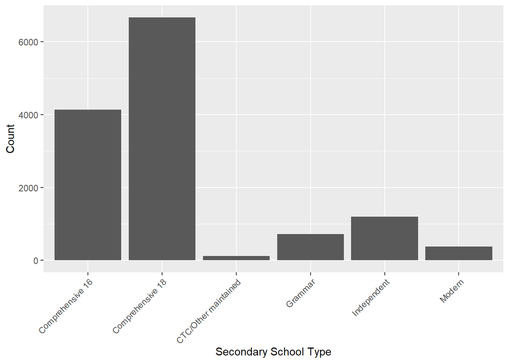

Figure 5: Distribution of Secondary School Types

```r
ggplot(youthdf, aes(x = pcschtype)) +
geom_bar() +
labs(x = "Secondary School Type", y = "Count") +
theme(axis.text.x = element_text(angle = 45, hjust = 1))
```

```r
youthdf %>%
  janitor::tabyl(satfren, pcschtype) %>%
  adorn_percentages("col") %>%
  adorn_pct_formatting(1)
```

```
 satfren Comprehensive 16 Comprehensive 18 CTC/Other maintained Grammar
      No            48.6%            46.0%                57.8%   38.5%
     Yes            51.4%            54.0%                42.2%   61.5%
 Independent Modern
       22.5%  40.8%
       77.5%  59.2%
```

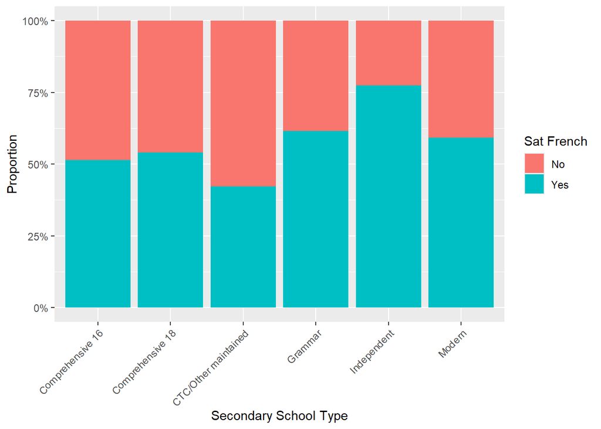

Figure 6: Proportion Sitting GCSE French by Secondary School Type

```r
ggplot(youthdf, aes(x = pcschtype, fill = satfren)) +
geom_bar(position = "fill") +
scale_y_continuous(labels = scales::percent_format()) +
labs(x = "Secondary School Type", y = "Proportion", fill = "Sat French") +
theme(axis.text.x = element_text(angle = 45, hjust = 1))
```

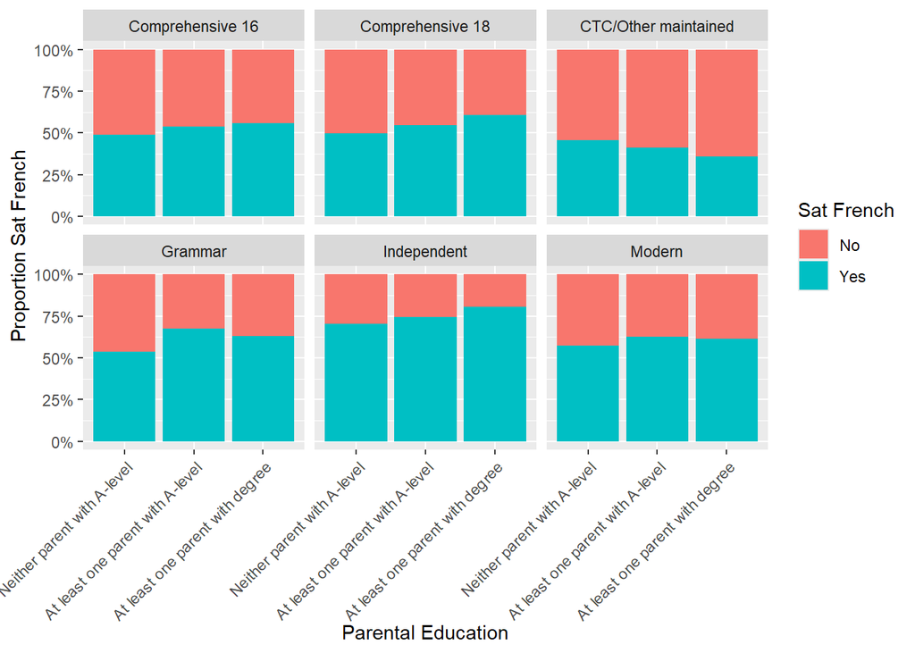

Figure 7: Faceted Plot - Sat French x Parental Education for each Secondary School Type

```r
ggplot(youthdf, aes(x = s1pared, fill = satfren)) +
  geom_bar(position = "fill") +
  facet_wrap(~ pcschtype) +
  scale_y_continuous(labels = scales::percent_format()) +
  labs(
    x = "Parental Education",
    y = "Proportion Sat French",
    fill = "Sat French"
  ) +
  theme(axis.text.x = element_text(angle = 45, hjust = 1))
```

## Step 1: Build the model

```r
# Fit the model
logmodel2 <- glm(
  satfren_num ~ s1pared + pcschtype,
  data = youthdf,
  family = stats::binomial(link = "logit"),
  na.action = stats::na.exclude
)
```

## Step 2: Generate Summary Statistics to Assess Model Fit

### Step 2a: Summary of Model

```r
#Full summary of the model
summary(logmodel2)
```

```
Call:
glm(formula = satfren_num ~ s1pared + pcschtype, family = stats::binomial(link = "logit"),
    data = youthdf, na.action = stats::na.exclude)

Coefficients:
                                        Estimate Std. Error z value Pr(>|z|)
(Intercept)                             -0.06652    0.03463  -1.921 0.054769
s1paredAt least one parent with A-level  0.20421    0.04590   4.449 8.64e-06
s1paredAt least one parent with degree   0.38101    0.04311   8.838  < 2e-16
pcschtypeComprehensive 18                0.07760    0.03989   1.945 0.051756
pcschtypeCTC/Other maintained           -0.39117    0.19114  -2.046 0.040709
pcschtypeGrammar                         0.30223    0.08410   3.594 0.000326
pcschtypeIndependent                     1.03692    0.07775  13.336  < 2e-16
pcschtypeModern                          0.32112    0.11018   2.914 0.003563

(Intercept)                             .
s1paredAt least one parent with A-level ***
s1paredAt least one parent with degree  ***
pcschtypeComprehensive 18               .
pcschtypeCTC/Other maintained           *
pcschtypeGrammar                        ***
pcschtypeIndependent                    ***
pcschtypeModern                         **
---
Signif. codes:  0 '***' 0.001 '**' 0.01 '*' 0.05 '.' 0.1 ' ' 1

(Dispersion parameter for binomial family taken to be 1)

    Null deviance: 18124  on 13200  degrees of freedom
Residual deviance: 17736  on 13193  degrees of freedom
AIC: 17752

Number of Fisher Scoring iterations: 4
```

### Step 2b: Omnibus Test of Model

```r
#Chi-square plus significance
lmtest::lrtest(logmodel2)
```

```
Likelihood ratio test

Model 1: satfren_num ~ s1pared + pcschtype
Model 2: satfren_num ~ 1
  #Df LogLik Df  Chisq Pr(>Chisq)
1   8  -8868
2   1  -9062 -7 387.88  < 2.2e-16 ***
---
Signif. codes:  0 '***' 0.001 '**' 0.01 '*' 0.05 '.' 0.1 ' ' 1
```

### Step 2c: Pseudo R2 Statistics

```r
#Pseudo Rsquared
DescTools::PseudoR2(logmodel2, which="CoxSnell")
```

```
  CoxSnell
0.02895493
```

```r
DescTools::PseudoR2(logmodel2, which="Nagelkerke")
```

```
Nagelkerke
0.03878063
```

```r
performance::r2(logmodel1) # Will return Tujur's Pseudo R2
```

```
# R2 for Logistic Regression
  Tjur's R2: 0.013
```

## (Optional): Generate a Stargazer Report

```r
#Summary of the model with co-efficients
stargazer(logmodel2, type="text", star.cutoffs = c(0.05, 0.01, 0.001))
```

```
=====================================================================
                                             Dependent variable:
                                        -----------------------------
                                                 satfren_num
---------------------------------------------------------------------
s1paredAt least one parent with A-level           0.204***
                                                   (0.046)

s1paredAt least one parent with degree            0.381***
                                                   (0.043)

pcschtypeComprehensive 18                           0.078
                                                   (0.040)

pcschtypeCTC/Other maintained                      -0.391*
                                                   (0.191)

pcschtypeGrammar                                  0.302***
                                                   (0.084)

pcschtypeIndependent                              1.037***
                                                   (0.078)

pcschtypeModern                                    0.321**
                                                   (0.110)

Constant                                           -0.067
                                                   (0.035)

---------------------------------------------------------------------
Observations                                       13,201
Log Likelihood                                   -8,868.015
Akaike Inf. Crit.                                17,752.030
=====================================================================
Note:                                   *p<0.05; **p<0.01; ***p<0.001
```

## Step 3: Calculate Odds Ratios and Predicted Probabilities

```r
# Odds ratios only (clean output)
parameters::parameters(logmodel2, exponentiate = TRUE) %>%
  as.data.frame() %>%
  dplyr::select(Parameter, OddsRatio = Coefficient)
```

```
Profiled confidence intervals may take longer time to compute.
  Use `ci_method="wald"` for faster computation of CIs.
```

```
                                Parameter OddsRatio
1                             (Intercept) 0.9356409
2 s1paredAt least one parent with A-level 1.2265617
3  s1paredAt least one parent with degree 1.4637632
4               pcschtypeComprehensive 18 1.0806920
5           pcschtypeCTC/Other maintained 0.6762653
6                        pcschtypeGrammar 1.3528704
7                    pcschtypeIndependent 2.8205052
8                         pcschtypeModern 1.3786730
```

```r
# Predicted probabilities by s1pared
emmeans::emmeans(logmodel2, ~ s1pared, type = "response")
```

```
 s1pared                           prob     SE  df asymp.LCL asymp.UCL
 Neither parent with A-level      0.539 0.0112 Inf     0.517     0.561
 At least one parent with A-level 0.590 0.0128 Inf     0.564     0.614
 At least one parent with degree  0.632 0.0114 Inf     0.609     0.654

Results are averaged over the levels of: pcschtype
Confidence level used: 0.95
Intervals are back-transformed from the logit scale
```

```r
# Predicted probabilities by pcschtype
emmeans::emmeans(logmodel2, ~ pcschtype, type = "response")
```

```
 pcschtype             prob      SE  df asymp.LCL asymp.UCL
 Comprehensive 16     0.532 0.00810 Inf     0.516     0.548
 Comprehensive 18     0.551 0.00631 Inf     0.539     0.564
 CTC/Other maintained 0.435 0.04640 Inf     0.347     0.527
 Grammar              0.606 0.01850 Inf     0.569     0.642
 Independent          0.762 0.01270 Inf     0.737     0.786
 Modern               0.611 0.02520 Inf     0.560     0.659

Results are averaged over the levels of: s1pared
Confidence level used: 0.95
Intervals are back-transformed from the logit scale
```

```r
# Full grid of predictions for ALL combinations

pred_grid <- emmeans::emmeans(
  logmodel2,
  ~ s1pared * pcschtype,   # <-- interaction in predictions, even if not in model
  type = "response"
)

summary(pred_grid)
```

```
 s1pared                          pcschtype             prob      SE  df
 Neither parent with A-level      Comprehensive 16     0.483 0.00865 Inf
 At least one parent with A-level Comprehensive 16     0.534 0.01160 Inf
 At least one parent with degree  Comprehensive 16     0.578 0.01100 Inf
 Neither parent with A-level      Comprehensive 18     0.503 0.00762 Inf
 At least one parent with A-level Comprehensive 18     0.554 0.01030 Inf
 At least one parent with degree  Comprehensive 18     0.597 0.00926 Inf
 Neither parent with A-level      CTC/Other maintained 0.388 0.04500 Inf
 At least one parent with A-level CTC/Other maintained 0.437 0.04710 Inf
 At least one parent with degree  CTC/Other maintained 0.481 0.04770 Inf
 Neither parent with A-level      Grammar              0.559 0.02010 Inf
 At least one parent with A-level Grammar              0.608 0.02010 Inf
 At least one parent with degree  Grammar              0.649 0.01820 Inf
 Neither parent with A-level      Independent          0.725 0.01500 Inf
 At least one parent with A-level Independent          0.764 0.01420 Inf
 At least one parent with degree  Independent          0.794 0.01170 Inf
 Neither parent with A-level      Modern               0.563 0.02630 Inf
 At least one parent with A-level Modern               0.613 0.02630 Inf
 At least one parent with degree  Modern               0.654 0.02510 Inf
 asymp.LCL asymp.UCL
     0.466     0.500
     0.512     0.557
     0.556     0.599
     0.488     0.518
     0.533     0.574
     0.579     0.615
     0.304     0.478
     0.348     0.530
     0.389     0.574
     0.519     0.598
     0.568     0.647
     0.613     0.684
     0.695     0.754
     0.735     0.791
     0.771     0.816
     0.511     0.614
     0.560     0.663
     0.603     0.701

Confidence level used: 0.95
Intervals are back-transformed from the logit scale
```

## Step 4: Assess Classification Performance

### Step 4a: Generate a ROC Curve, Sensistivity, Specificity and AUC

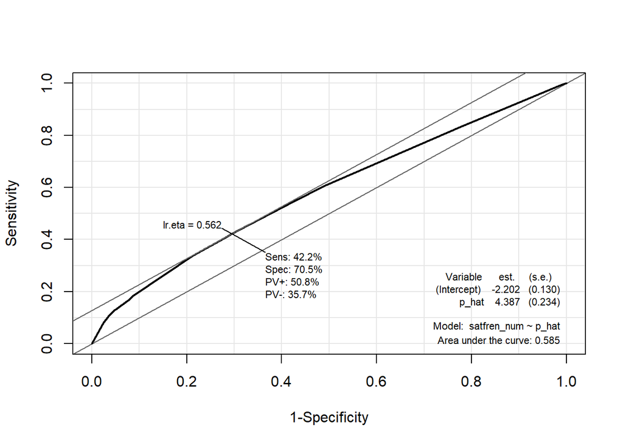

Figure 8: ROC Curve Model 2

```r
# Generate predicted probabilities for Model 2
p_hat <- stats::predict(logmodel2, type = "response")


# Build results2 data frame for Epi::ROC
results2 <- youthdf %>%
  dplyr::mutate(
    satfren_num = satfren_num,   # already created earlier
    p_hat = p_hat                # predicted probabilities
  ) %>%
  dplyr::select(satfren_num, p_hat) %>%     # only keep needed columns
  dplyr::filter(!is.na(satfren_num))        # remove NA cases

# Generate the curve
roc2 <-Epi::ROC(
  form = satfren_num ~ p_hat,
  data = results2,
  plot = "ROC"
)
```

### Step 4b: Generate a Confusion Matrix

```r
results2 <- youthdf %>%
  dplyr::mutate(
    actual = factor(satfren_num, levels = c(0,1)),
    pred_class = factor(
      ifelse(stats::predict(logmodel2, type = "response") > 0.5, 1, 0),
      levels = c(0,1)
    )
  )


cm <- yardstick::conf_mat(
  data = results2,
  truth = actual,
  estimate = pred_class
)

cm
```

```
          Truth
Prediction    0    1
         0 1300 1229
         1 4538 6134
```

## Step 5: Check the Model meets the Assumptions of Logistic Regression

### Step 5a: Linearity of Independent Variables with Log Odds

```r
#Check the assumption of linearity of independent variables and log odds using a Hosmer-Lemeshow test, if this is not statistically significant we are ok

generalhoslem::logitgof(youthdf$satfren_num, fitted(logmodel2))
```

```
    Hosmer and Lemeshow test (binary model)

data:  youthdf$satfren_num, fitted(logmodel2)
X-squared = 3.0885, df = 6, p-value = 0.7977
```

### Step 5b: Collinearity

```r
#Collinearity
vifmodel<-car::vif(logmodel2)
# You can ignore the warning messages
# GVIF^(1/(2*Df)) is the value of interest

vifmodel
```

```
              GVIF Df GVIF^(1/(2*Df))
s1pared   1.060265  2        1.014737
pcschtype 1.060265  5        1.005869
```

```r
#Tolerance
1/vifmodel
```

```
               GVIF  Df GVIF^(1/(2*Df))
s1pared   0.9431604 0.5       0.9854768
pcschtype 0.9431604 0.2       0.9941652
```

```r
#Guidelines:
#Tolerance < 0.1 → Serious multicollinearity
#Tolerance < 0.2 → Potential multicollinearity problem
#VIF > 10 → Serious multicollinearity (widely used rule of thumb)
#VIF > 5 → Concerning / needs investigation
#VIF between 1 and 5 → Acceptable
```

### Step 5c: Outliers and Influential Cases

```r
# 1. Cook's Distance
cook <- cooks.distance(logmodel2)

# View largest Cook's D values
head(sort(cook, decreasing = TRUE))
```

```
       1286        1562        1967        2384        2682        3569
0.001711676 0.001711676 0.001711676 0.001711676 0.001711676 0.001711676
```

```r
# Flag influential cases (common threshold: D > 1)
which(cook > 1)
```

```
named integer(0)
```

```r
# 2. Leverage (Hat values)
lev <- hatvalues(logmodel2)

# View highest leverage cases
head(sort(lev, decreasing = TRUE))
```

```
       1424        3370        3371        3372        3566        3567
0.009107665 0.009107665 0.009107665 0.009107665 0.009107665 0.009107665
```

```r
#Count how many exceed threshold
sum(lev > lev_threshold)
```

```
[1] 4123
```

```r
#Count how many > .2
sum(lev > 0.2)
```

```
[1] 0
```

```r
# Flag high leverage cases
# Rule of thumb: h_i > 2*(k+1)/n
k <- length(coef(logmodel2)) - 1  # number of predictors
n <- nobs(logmodel2)
lev_threshold <- 2*(k+1)/n


print(paste("Threshold is: ", lev_threshold))
```

```
[1] "Threshold is:  0.00121202939171275"
```

```r
which(lev > lev_threshold)
```

[output not shown]

[output cut: 171 more lines]

```r
# 3. DFBetas (influence on individual coefficients)
dfb <- dfbeta(logmodel2)

# Identify cases with large DFBetas (|DFB| > 1 is concerning)
which(abs(dfb) > 1, arr.ind = TRUE)
```

```
     row col
```

```r
# 4. Standardised (Pearson) residuals
pearson_resid <- rstandard(logmodel2, type = "pearson")

# Flag large residuals (|residual| > 2 or > 3)
which(abs(pearson_resid) > 2)
```

```
named integer(0)
```

```r
# Optional: look at the largest ones
head(sort(abs(pearson_resid), decreasing = TRUE))
```

```
       9       26       29       34       39       45
1.966232 1.966232 1.966232 1.966232 1.966232 1.966232
```

```r
# 5. Deviance residuals
dev_resid <- residuals(logmodel2, type = "deviance")

# Flag extreme deviance residuals
which(abs(dev_resid) > 2)
```

```
named integer(0)
```

## Step 6: Report

A binary logistic regression analysis was conducted to examine whether parental education level and secondary school type predicted the likelihood that a student sat GCSE French. The dataset contained 13,201 observations, with the outcome variable coded 0 = Did not sit French and 1 = Sat French.

Two predictors were entered into the model:

- Parental education:
  - Neither parent with A-level (reference category)
  - At least one parent with A-level
  - At least one parent with degree
- School type:
  - Comprehensive 16 (reference category)
  - Comprehensive 18
  - CTC/Other maintained
  - Grammar
  - Independent
  - Modern

Higher parental education was associated with higher odds of taking GCSE French relative to students whose parents did not have an A-level:

- At least one parent with A-level: OR ≈ 1.23, p < .001
- At least one parent with degree: OR ≈ 1.46, p < .001

School type also showed meaningful differences compared with Comprehensive 16:

- Comprehensive 18: OR ≈ 1.08, p = .052
- CTC/Other maintained: OR ≈ 0.68, p = .041
- Grammar: OR ≈ 1.35, p < .001
- Independent: OR ≈ 2.82, p < .001
- Modern: OR ≈ 1.38, p = .004

Students attending independent schools had the highest odds of taking French, more than doubling those of the reference group.

Estimated probabilities (averaged over the other predictor) showed clear group differences.

- By parental education:
  - Neither parent with A-level: 0.54
  - At least one parent with A-level: 0.59
  - At least one parent with degree: 0.63
- By school type:
  - Comprehensive 16: 0.53
  - Comprehensive 18: 0.55
  - CTC/Other maintained: 0.44
  - Grammar: 0.61
  - Independent: 0.76
  - Modern: 0.61

The full prediction grid demonstrated that the lowest probabilities (≈0.39–0.48) occurred for students in CTC/Other maintained schools with lower parental education, while the highest probabilities (≈0.79) were observed for students with degree-educated parents attending independent schools.

ROC analysis indicated limited classification accuracy, with AUC ≈ 0.56–0.58, reflecting poor discrimination between students who did and did not take French. Using a standard 0.5 threshold resulted in reasonable sensitivity but low specificity, as predicted probabilities clustered closely together and did not separate the two outcome groups well.

***Conclusion**

Both parental education and school type were statistically significant predictors of GCSE French participation. Students from more highly educated families and those attending grammar, modern, or especially independent schools were more likely to take French. Although the predictors provided clear group differences in odds and predicted probabilities, the overall explanatory power of the model remained modest, and classification performance was limited. This suggests that while family background and school context contribute to French participation, additional individual and institutional factors are likely to play an important role.

# Comparison Model 1 v Model 2

Model 2 also demonstrated a notable reduction in AIC in comparison to Model 1, decreasing from 17964 to 17752. This indicates that model2 achieved better explanatory power while balancing model complexity more efficiently providing strong evidence that adding school type improves the model quality.

In both models, parental education remained a statistically significant predictor. However, the size of the effects was reduced in Model 2 once school type was included, suggesting that part of the apparent influence of parental education in Model 1 may be explained by differences in school environment.

School type itself exhibited meaningful variation. Students attending grammar, modern, and especially independent schools had higher odds of taking GCSE French than those in Comprehensive 16 schools. Independent school students showed the largest effect, with odds more than twice as high. Conversely, students in CTC/Other maintained schools had lower odds of taking French. These differences revealed that school context contributes significant additional information beyond family background.

Model 1 produced a narrow range of predicted probabilities (approximately 0.51–0.64), reflecting the limited variability captured by parental education alone. Model 2 generated a much wider range (approximately 0.39–0.79 across combinations of parental education and school type), demonstrating that the addition of school type substantially increased the model’s ability to differentiate between higher- and lower-probability groups.

Despite improved fit, Model 2 did not substantially outperform Model 1 in classification accuracy. Both models produced AUC values around 0.56–0.58, indicating poor discrimination. At a 0.5 probability threshold, both models predicted most students as having taken French, leading to high sensitivity but low specificity. Thus, while Model 2 better explains variation in the outcome, neither model provides strong individual-level predictions.

## Conclusion

Overall, Model 2 represents a clearer and more informative explanation of GCSE French participation. While parental education alone showed a statistically significant association with uptake, adding school type revealed much larger and more meaningful group differences. However, the predictive usefulness of both models remained limited. This suggests that although family background and school environment are important, there are other factors likely play a substantial role in determining whether students take GCSE French.

# References

Connolly, P. (2007). Quantitative Data Analysis in Education: A Critical Introduction Using SPSS. Routledge.